# Statistical Analysis of CO2 Emissions From Vehicles

Alex Zakrzeski

## I. Introduction

### Background Information

Over the past three decades, climate change has been a subject of global interest. Researchers have discovered numerous factors that contribute to climate change, with CO2 emissions from vehicles being a noteworthy instance. This year alone, experts forecast that CO2 emissions from vehicles will exceed three billion metric tons. CO2 emissions from vehicles are extremely harmful because they are a driving force for increasing temperatures and rising sea levels. A solution to lessen the adverse effects of CO2 emissions from vehicles is for manufacturers to produce vehicles that emit relatively low levels of CO2 emissions. This manufacturer initiative has been ongoing for years, with Toyota releasing the world’s first mass-produced hybrid vehicle in 1997. Still, vehicle manufacturers need to implement more initiatives to decelerate climate change. Finally, there is a significant urgency for new strategies to be developed to further educate the public on how CO2 emissions from vehicles are accelerating climate change.

### Data Overview

For this analysis, a data set from the Canadian government’s official open data website was used. The data were collected over a seven-year period and comprise 7,385 vehicles manufactured on three continents: Asia, Europe, and North America. There are nine variables in the data set. Six of these variables are categorical; the other three are numeric. Below is a summary of the variables used in this analysis.

- Categorical Variables
  - *Number of Cylinders:* The number of cylinders in the engine of a vehicle
  - *Fuel Type:* The fuel type of the vehicle
  - *Make:* The company that manufactured the vehicle
  - *Model:* The model of the vehicle
  - *Transmission:* The type of transmission for the vehicle
  - *Vehicle Class:* The class of the vehicle by utility, capacity, and weight
- Quantitative Variables
  - *CO2 Emissions:* The tailpipe carbon dioxide emissions in grams per kilometer
  - *Engine Size:* The engine’s displacement in liters
  - *Fuel Consumption:* The combined city/highway fuel consumption in liters per 100 km

### Research Question and Design

The research question for this analysis was: What is the best predictor or combination of predictors for high CO2 emissions in vehicles? The dependent variable in the research was “CO2 Emissions,” and the remaining eight variables were independent variables. The research design encompassed numerous statistical techniques, including descriptive statistics, correlation tests, visualization, ANOVA, linear regression, logistic regression, and K-Nearest Neighbors. Overall, the findings offer a clearer understanding of which characteristics of vehicles are the most responsible for high CO2 emissions, therefore making individuals more likely to choose to drive eco-friendly vehicles to slow climate change.

## II. Data Preparation

### Data Cleaning

Prior to the exploratory data analysis, several data-cleaning steps were taken, which included checking for missing values, manipulating strings, renaming variables, and converting data types. The purpose of the data cleaning was to enhance the quality and integrity of the data for the next steps of the analysis.

```r
data = read_csv("co2_emissions_canada.csv")

glimpse(data)

nacount <- function(x) {
  data <- x %>%
    summarize(across(.fns = ~sum(is.na(.)))) %>%
    pivot_longer(cols = everything(),
                 names_to = "variables",
                 values_to = "na_count") %>%
    filter(na_count > 0)
}

miss_vals  <- nacount(data)

unique(data$Make)

data <- data %>%
  mutate(Make = str_to_title(data$Make),
         Make = str_replace(Make, "Bmw", "BMW"),
         Make = str_replace(Make, "Fiat", "FIAT"),
         Make = str_replace(Make, "Gmc", "GMC"),
         Make = str_replace(Make, "Mini", "MINI"),
         Make = str_replace(Make, "Srt", "SRT"))

unique(data$`Vehicle Class`)

data <- data %>%
  rename(Class = `Vehicle Class`) %>%
  mutate(Class = str_to_title(data$`Vehicle Class`),
         Class = str_replace(Class, "Van - Cargo", "Cargo Van"),
         Class = str_replace(Class, "Pickup Truck - Small", "Small Pickup Truck"),
         Class = str_replace(Class, "Suv - Small", "Small SUV"),
         Class = str_replace(Class, "Station Wagon - Small", "Small Station Wagon"),
         Class = str_replace(Class, "Van - Passenger", "Passenger Van"),
         Class = str_replace(Class, "Suv - Standard", "Standard SUV"),
         Class = str_replace(Class, "Pickup Truck - Standard", "Standard Pickup Truck"),
         Class = str_replace(Class, "Station Wagon - Mid-Size", "Mid-Size Station Wagon"))

data <- data %>%
  rename(Engine_Size = `Engine Size(L)`,
         Fuel_Type = `Fuel Type`,
         Fuel_Consumption = `Fuel Consumption Comb (L/100 km)`,
         Emissions = `CO2 Emissions(g/km)`) %>%
  mutate(Cylinders = factor(Cylinders))
```

### Data Wrangling

After the data was cleaned, several data-wrangling steps were taken, which included creating new variables, grouping data, and aggregating data. The purpose of data wrangling was to make the data more efficient and insightful.

```r
unique(data$Make)

usa_make <- c("Buick", "Cadillac", "Chevrolet", "Chrysler", "Dodge", "Ford",
              "GMC", "Jeep", "Lincoln", "Ram", "SRT")

eur_make <- c("Alfa Romeo", "Aston Martin", "Audi", "Bentley", "BMW","FIAT",
              "Jaguar", "Lamborghini", "Land Rover", "Maserati", "Mercedes-Benz",
              "MINI", "Porsche", "Rolls-Royce", "Smart", "Volkswagen", "Volvo")

asia_make <- c("Acura", "Honda", "Hyundai", "Infiniti", "Kia", "Lexus", "Mazda",
               "Mitsubishi", "Nissan", "Scion", "Subaru", "Toyota", "Genesis",
               "Bugatti")

data %>%
  select(Emissions) %>%
  filter(Emissions %in% c(250, 251))

data <- data %>%
  mutate(Location_Make = case_when(Make %in% usa_make ~ "USA",
                                   Make %in% eur_make ~ "EUR",
                                   Make %in% asia_make ~ "Asia"),
         Emissions_Lvl = if_else(Emissions >= mean(Emissions),
                                 "Above Average",
                                 "Below Average"))

unique(data$Location_Make)

loc_lvl_count <- data %>%
  group_by(Location_Make, Emissions_Lvl) %>%
  summarize(Frequency = n())

loc_lvl_count <- loc_lvl_count %>%
  mutate(Location_Make = factor(Location_Make, levels = c("Asia", "USA", "EUR")))

unique(data$Class)

data %>%
 group_by(Class) %>%
 summarize(count = n())

class_avgs <- data %>%
  filter(Class == "Small Pickup Truck" | Class == "Standard Pickup Truck" |
         Class == "Small Station Wagon" | Class == "Mid-Size Station Wagon" |
         Class == "Small SUV" | Class == "Standard SUV") %>%
  mutate(Class1 = case_when(Class == "Small Pickup Truck" |
                            Class == "Standard Pickup Truck" ~ "Pickup Truck",
                            Class == "Small Station Wagon" |
                            Class == "Mid-Size Station Wagon" ~ "Station Wagon",
                            Class == "Small SUV" |
                            Class == "Standard SUV" ~ "SUV"),
         Class2 = case_when(Class == "Small Pickup Truck" |
                            Class == "Small Station Wagon" |
                            Class == "Small SUV" ~ "Small",
                            Class == "Standard Pickup Truck" |
                            Class == "Mid-Size Station Wagon" |
                            Class == "Standard SUV" ~ "Mid-Size"),
         Class2 = factor(Class2, levels = c("Small", "Mid-Size"))) %>%
  group_by(Class1, Class2) %>%
  summarize(avg_em = mean(Emissions))

unique(data$Fuel_Type)

ft_avgs <- data %>%
  filter(Fuel_Type != "N") %>%
  group_by(Fuel_Type) %>%
  summarize(avg_fc = round(mean(Fuel_Consumption), 2)) %>%
  arrange(desc(avg_fc)) %>%
  mutate(Fuel_Type = factor(Fuel_Type, levels = c("D", "X", "Z", "E"),
                            labels = c("Diesel Fuel", "Regular Gasoline",
                                       "Premium Gasoline", "Ethanol Fuel")))

corr_data1 <- data %>%
  select_if(is.numeric)

cm <- cor(corr_data1)

colnames(cm) <- c("Engine Size", "Fuel Consumption", "Emissions")

corr_data2 <- data %>%
  mutate(Cylinders = as.numeric(Cylinders),
         Emissions_Lvl = if_else(Emissions_Lvl == "Above Average", 1 , 0)) %>%
  select(Emissions, Cylinders, Emissions_Lvl)

mode1 <- data %>%
  group_by(Emissions) %>%
  count() %>%
  arrange(desc(n)) %>%
  head(1)

mode2 <- data %>%
  group_by(Engine_Size) %>%
  count() %>%
  arrange(desc(n)) %>%
  head(1)

emissions_outliers <- data %>%
  select(Emissions) %>%
  filter(Emissions > quantile(Emissions, 0.75) + 1.5 * IQR(Emissions) |
         Emissions < quantile(Emissions, 0.25) - 1.5 * IQR(Emissions))
```

## III. Data Exploration

### Descriptive Statistics

The first step in this exploratory data analysis was to analyze the descriptive statistics of the numeric variables that measure central tendency and dispersion. For this analysis, the descriptive statistics of the variables Engine Size and CO2 Emissions are especially noteworthy and will be examined in further detail. The mean of CO2 emissions was 250.58, the median was 246, and the mode was 242. The mode of this variable indicates that 242 is the most common value for a vehicle’s CO2 emissions, with 85 vehicles in the data taking this value. The mean of Engine Size was 3.16, the median was 3, and the mode was 2. The mean of this variable indicates that the average engine size for the vehicles in the data is 3.16, whereas the median displays that the middle point of the distribution for engine size is 3. This middle point in the distribution is also known as the second quartile, indicating that 50% of the values for engine size are less than or equal to 3. A descriptive statistics table for the numeric variables is presented below.

```r
data %>%
  select_if(is.numeric) %>%
  rename(`Engine Size` = Engine_Size, `Fuel Consumption` = Fuel_Consumption,
         `CO2 Emissions` = Emissions) %>%
  describe() %>%
  select(n, mean, sd, median, min, max) %>%
  rename(N = n, Mean = mean, `St. Dev.` = sd, Median = median, Min = min, Max = max) %>%
  as_tibble(rownames = "Variable") %>%
  gt() %>%
  cols_label(Variable = md("**Variable**"), N = md("**N**"),
             Mean = md("**Mean**"),`St. Dev.` = md("**St. Dev.**"),
             Median = md("**Median**"), Min = md("**Min**"), Max = md("**Max**")) %>%
  fmt_number(N, decimals = 0, sep_mark = ",") %>%
  fmt_number(Mean, decimals = 2) %>%
  fmt_number(`St. Dev.`, decimals = 2) %>%
  fmt_number(Median, drop_trailing_zeros = TRUE) %>%
  fmt_number(Max, drop_trailing_zeros = TRUE) %>%
  cols_align("center")
```

| **Variable** | **N** | **Mean** | **St. Dev.** | **Median** | **Min** | **Max** |
| --- | --- | --- | --- | --- | --- | --- |
| Engine Size | 7,385 | 3.16 | 1.35 | 3 | 0.9 | 8.4 |
| Fuel Consumption | 7,385 | 10.98 | 2.89 | 10.6 | 4.1 | 26.1 |
| CO2 Emissions | 7,385 | 250.58 | 58.51 | 246 | 96.0 | 522 |

### Stacked Bar Chart

All the vehicles in the data were produced in the United States, Europe, or Asia. The stacked bar chart below displays the number of vehicles in the data and the number of vehicles that have above- and below-average CO2 emissions for each manufacturing location. The chart shows that Europe manufactured the most vehicles, followed closely by the US, then Asia. However, Asia is the manufacturing location with the largest portion of vehicles that have below-average CO2 emissions levels. This visualization is presented below.

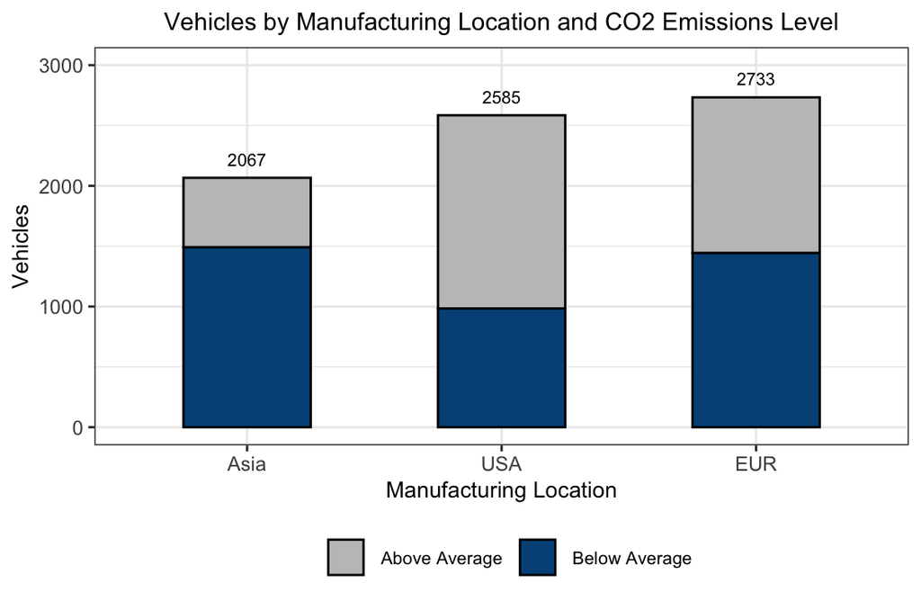

```r
ggplot(data = loc_lvl_count,
       mapping = aes(x = Location_Make, y = Frequency, fill = Emissions_Lvl,)) +
  geom_bar(position = "stack", stat = "identity", color = "black", width = 0.5) +
  geom_text(aes(label = after_stat(y), group = Location_Make),
            stat = 'summary', fun = sum, vjust = -1, size = 2.75) +
  scale_fill_manual(values = c("#c0c2c4", "#005288")) +
  ylim(c(0,3000)) +
  labs(title = "Vehicles by Manufacturing Location and CO2 Emissions Level",
       x = "Manufacturing Location", y = "Vehicles") +
  guides(fill = guide_legend(title = "")) +
  theme_bw() +
  theme(plot.title = element_text(hjust = 0.5, size = 11),
        axis.title = element_text(size = 10),
        axis.text.x = element_text(size = 9),
        axis.text.y = element_text(size = 9),
        legend.text = element_text(size = 8),
        legend.position = "bottom",
        legend.spacing.x = unit(0.25, "cm"))
```

### Grouped Bar Chart

The average CO2 emissions for certain vehicle classes (i.e., pickup truck, station wagon, and SUV) and their respective sizes (mid-size and small) was examined. A grouped bar chart displayed below shows the average CO2 emissions for various combinations of vehicle class and size. As anticipated, all the mid-size vehicles have larger CO2 emissions than their smaller counterparts. SUV was the vehicle class with the largest difference in average CO2 emissions between its two sizes.

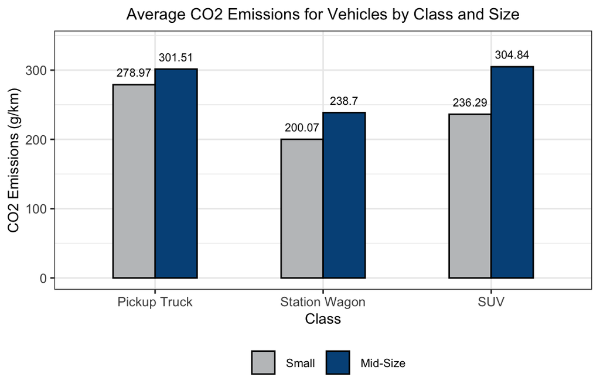

```r
ggplot(data = class_avgs, mapping = aes(x = Class1, y = avg_em, fill = Class2)) +
  geom_col(position = "dodge", color = "black", width = 0.5) +
  ylim(0, 340) +
  geom_text(aes(label = round(avg_em, 2)), position = position_dodge(0.5),
            color = "black", vjust = -1, hjust = 0.5, size = 2.75) +
  scale_fill_manual(values = c("#c0c2c4", "#005288")) +
  labs(title = "Average CO2 Emissions for Vehicles by Class and Size",
       x = "Class", y = "CO2 Emissions (g/km)") +
  guides(fill = guide_legend("")) +
  theme_bw() +
  theme(plot.title = element_text(hjust = 0.5, size = 11),
        axis.title = element_text(size = 10),
        axis.text.x = element_text(size = 9),
        axis.text.y = element_text(size = 9),
        legend.text = element_text(size = 8),
        legend.position = "bottom",
        legend.spacing.x = unit(0.25, "cm"))
```

### Horizontal Bar Chart

In the data, a vehicle can have five different values for its fuel type. Only one vehicle took natural gas; the most common fuel type was regular gasoline. A horizontal bar chart to display the average fuel consumption among the vehicles for the categories of fuel type except for natural gas was created. Ethanol fuel had the highest average fuel consumption, and diesel fuel had the lowest average. The horizontal bar chart supports the preliminary research findings and is displayed below.

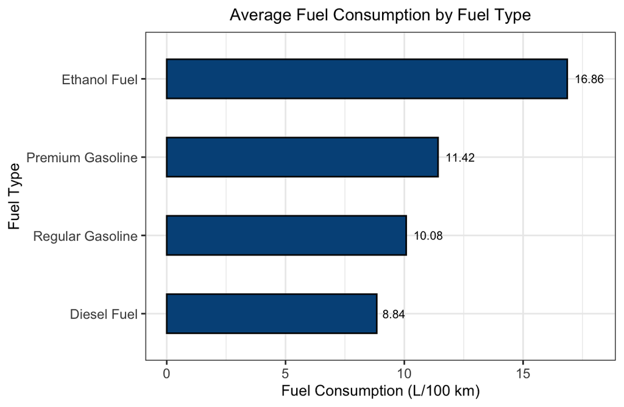

```r
ggplot(data = ft_avgs, mapping = aes(x = Fuel_Type, y = avg_fc)) +
  geom_col(color = "black", width = 0.5, fill = "#005288") +
  ylim(0, 18) +
  geom_text(aes(label = avg_fc), vjust = 0.5, hjust = -0.25, colour = "black", size = 2.75) +
  coord_flip() +
  labs(title ="Average Fuel Consumption by Fuel Type",
       x = "Fuel Type", y = "Fuel Consumption (L/100 km)") +
  theme_bw() +
  theme(plot.title = element_text(hjust = 0.5, size = 11),
        axis.title = element_text(size = 10),
        axis.text.x = element_text(size = 9),
        axis.text.y = element_text(size = 9))
```

### Correlation Matrix

The Pearson correlation coefficients between the numeric variables in the data were generated, which shows the linear strength of the relationship between two continuous variables. A correlation matrix was created to visually display this. All the numeric variables have a high positive correlation (> 80%) with CO2 emissions. The analysis will further investigate the relationship between a vehicle’s engine size and its C02 emissions in this analysis. The correlation coefficient of these variables indicates that as the engine size of a vehicle increases, its level of CO2 emissions increases as well. This correlation matrix is displayed below. Because Cylinders is an ordinal variable, the Spearman rank correlation coefficient between Cylinders and CO2 Emissions was generated. This correlation test measured the level of monotonicity between the variables rather than the linearity. The correlation was 0.85, which indicates a strong nonlinear relationship.

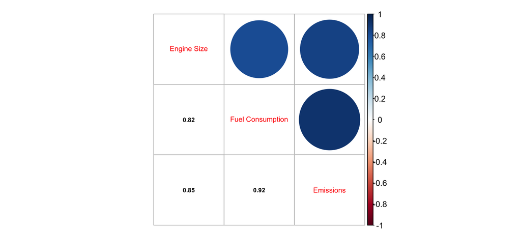

```r
sp_cor <- cor(corr_data2$Cylinders, corr_data2$Emissions, method = "spearman")
corrplot.mixed(cm, lower.col = "black", number.cex = 0.6, tl.cex = 0.7,
               mar = c(0, 0, 0.75, 3.5))
```

### Scatter Plot

Next, the analysis explored the relationship between a vehicle’s engine size and its C02 emissions in another data visualization, a scatter plot. Engine Size is on the x-axis, and CO2 Emissions is on the y-axis. The scatter plot displays a strong positive correlation. The linear regression line displays the line of best fit for the data. Overall, this linear regression line illustrates that the engine size of vehicles is an excellent predictor of CO2 emissions. This scatter plot is displayed below.

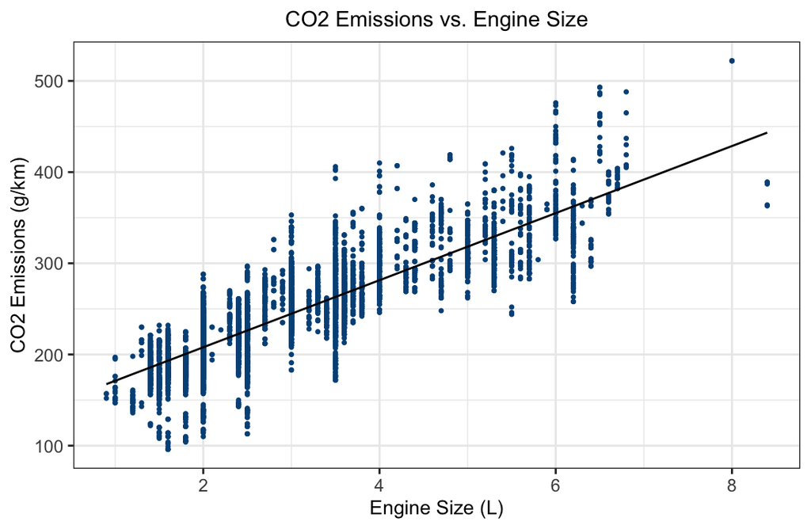

```r
ggplot(data = data, mapping = aes(x = Engine_Size, y = Emissions)) +
  geom_point(color = "#005288", size = 0.6) +
  geom_smooth(method = lm, se = FALSE, col = "black", size = 0.5) +
  labs(title = "CO2 Emissions vs. Engine Size",
       x = "Engine Size (L)", y = "CO2 Emissions (g/km)") +
  theme_bw() +
  theme(plot.title = element_text(hjust = 0.5, size = 11),
        axis.title = element_text(size = 10),
        axis.text.x = element_text(size = 9),
        axis.text.y = element_text(size = 9))
```

### Density Plots

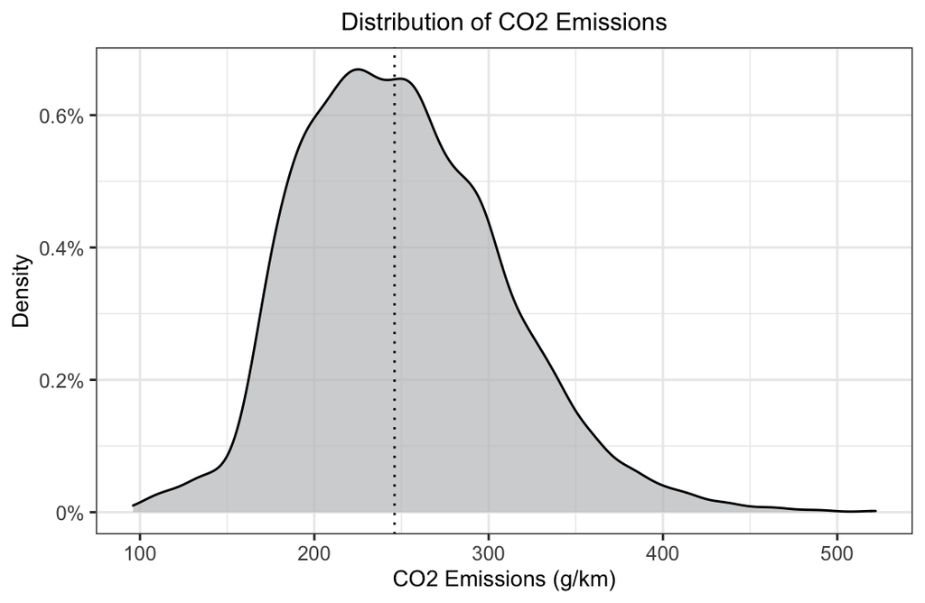

```r
ggplot(data = data, mapping = aes(x = Emissions)) +
  geom_density(fill = "#c0c2c4", alpha = 0.7) +
  geom_vline(xintercept = median(data$Emissions), linetype = "dotted") +
  scale_y_continuous(labels = function(x) paste0(x * 100, "%")) +
  labs(title = "Distribution of CO2 Emissions", x = "CO2 Emissions (g/km)", y = "Density") +
  theme_bw() +
  theme(plot.title = element_text(hjust = 0.5, size = 11),
        axis.title = element_text(size = 10),
        axis.text.x = element_text(size = 9),
        axis.text.y = element_text(size = 9))
```

The distribution of Engine Size is examined by creating a kernel density plot. The vertical line displays the median value for Engine Size. The distribution displays a right skew. This was anticipated this because the mean of the Engine Size is larger than its median. Finally, the distribution appears to be multimodal. This density plot is displayed below.

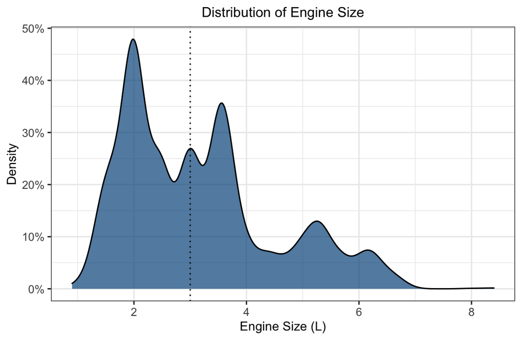

```r
ggplot(data = data, mapping = aes(x = Engine_Size)) +
  geom_density(fill = "#005288", alpha = 0.7) +
  geom_vline(xintercept = median(data$Engine_Size), linetype = "dotted") +
  scale_y_continuous(labels = function(x) paste0(x * 100, "%")) +
  labs(title = "Distribution of Engine Size", x = "Engine Size (L)", y = "Density") +
  theme_bw() +
  theme(plot.title = element_text(hjust = 0.5, size = 11),
        axis.title = element_text(size = 10),
        axis.text.x = element_text(size = 9),
        axis.text.y = element_text(size = 9))
```

### Box Plot

Upon visual inspection of the density plot of CO2 Emissions, outliers likely exist in the distribution’s upper tail. A box plot is created to display the variable’s distribution. The interquartile range method displays all 80 of the outliers for CO2 emissions that surpass the upper whisker. This box plot is displayed below.

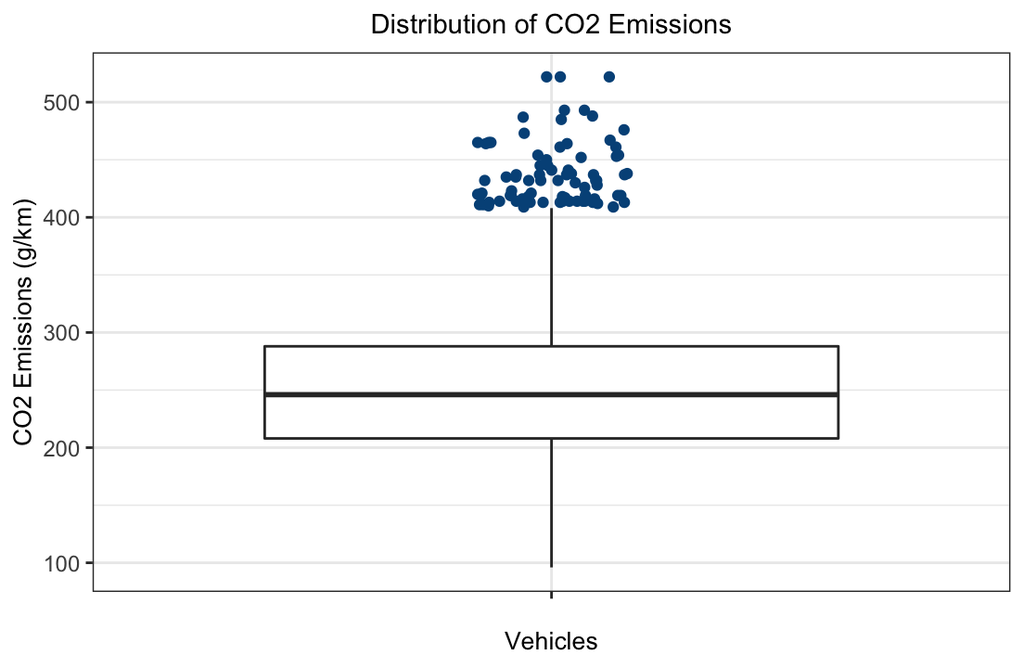

```r
ggplot(data = data, mapping = aes(x = "", y = Emissions)) +
  geom_boxplot(outlier.shape = NA) +
  geom_jitter(data = emissions_outliers, color = "#005288", height = 0, width = 0.1) +
   labs(title = "Distribution of CO2 Emissions",
        x = "Vehicles", y = "CO2 Emissions (g/km)") +
  theme_bw() +
   theme(plot.title = element_text(hjust = 0.5, size = 11),
        axis.title = element_text(size = 10),
        axis.text.x = element_text(size = 9),
        axis.text.y = element_text(size = 9))
```

## IV. Statistical Modeling

### ANOVA

Three ANOVA models are built. Model 1, the first ANOVA model, is a two-way ANOVA that displays CO2 Emissions as a function of Number of Cylinders and Fuel Type. At the 1% significance level, Number of Cylinders is statistically significant. Then, at the 5% significance level, Fuel Type is statistically significant. The model’s residual variance is 7,400,174. Model 2, the second ANOVA model, is a two-way ANOVA that displays CO2 Emissions as a function of the interaction between Number of Cylinders and Fuel Type. At the 1% significance level, Number of Cylinders and the interaction between Number of Cylinders and Fuel Type are statistically significant. At the 5% significance level, Fuel Type is statistically significant. The model’s residual variance is 6,995,135, which is lower than that of the first ANOVA model.

The AIC for both models is generated. The model with the smallest AIC will be the best-performing model. The second model, a two-way ANOVA with the interaction term, has the lower AIC; thus, it is the best fit. Now it will be checked whether Model 2 fits the assumption of homoscedasticity. This assumption is met when the variance of the residuals in the model is constant. A residual versus fitted plot is generated from Model 2 to visually inspect this. After further consideration, the assumption of homoscedasticity is not met, and the residuals are heteroscedastic. The necessary steps will be taken to make the residuals of the ANOVA model homoscedastic. The residual vs. fitted plot is displayed below.

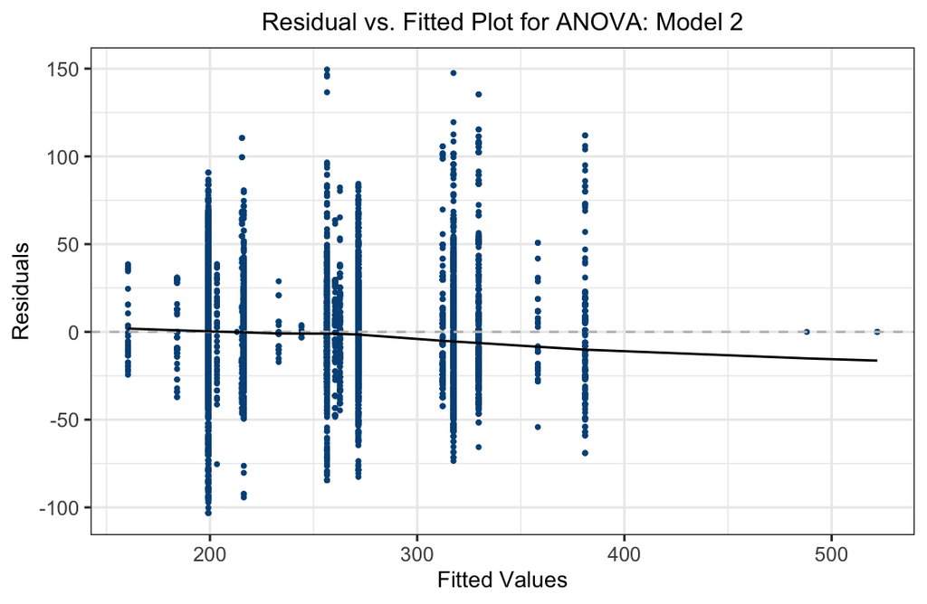

```r
data <- data %>%
  mutate(Cylinders = as.factor(Cylinders),
         Fuel_Type = as.factor(Fuel_Type))

levels(data$Cylinders)

levels(data$Fuel_Type)

twa1 <- aov(Emissions ~ Cylinders + Fuel_Type, data = data)

summary(twa1)

twa2 <- aov(Emissions ~ Cylinders * Fuel_Type, data = data)

summary(twa2)

model_set <- list(twa1, twa2)
model_names <- c("twa1", "twa2")

aictab(model_set, modnames = model_names)

model_frame1 <- fortify(twa2)

smoothed1 <- as.data.frame(with(model_frame1, lowess(x = .fitted, y = .resid)))

ggplot(data = twa2, aes(x = .fitted, y = .resid)) +
  geom_point(color = "#005288", size = 0.6) +
  geom_hline(yintercept = 0, color = "grey", linetype = "dashed") +
  geom_path(data = smoothed1, aes(x = x, y = y), col = "black") +
  labs(title =
         "Residual vs. Fitted Plot for ANOVA: Model 2",
       x = "Fitted Values", y = "Residuals") +
  theme_bw() +
   theme(plot.title = element_text(hjust = 0.5, size = 11),
        axis.title = element_text(size = 10),
        axis.text.x = element_text(size = 9),
        axis.text.y = element_text(size = 9))
```

In the data exploration, in the previous section of this statistical analysis, a box plot was created to display the distribution of CO2 Emissions for the vehicles. It is apparent in this visualization that there are numerous outliers when looking at the distribution of CO2 Emissions. These outliers can be seen outside the upper whisker of the box plot. The interquartile range method removes these outliers from the distribution of CO2 Emissions. Ultimately, 80 outliers are removed from the distribution of CO2 Emissions, and as a result, all the observations that contain outliers are dropped. Model 3, the third ANOVA model, is a two-way ANOVA model with the same dependent variable and independent variables from Model 2, but the outliers from CO2 Emissions are excluded. At the 1% significance level, Number of Cylinders, Fuel Type, and the interaction between Number of Cylinders and Fuel Type are all statistically significant. The model’s residual variance is 6,245,676. A residual versus fitted plot is generated from this model, which displays that the residuals for this model are homoscedastic. Now, this statistical assumption for ANOVA is met. The residual vs. fitted plot is displayed below.

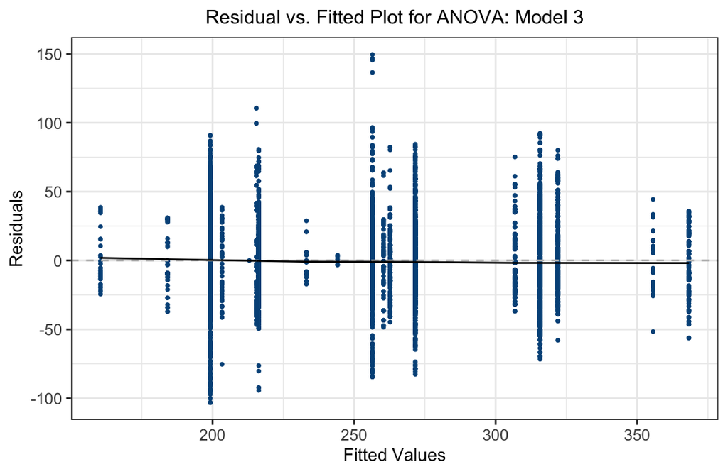

```r
data <- data %>%
  mutate(Co2Em_Outliers = if_else(
    Emissions > quantile(Emissions, 0.75) + 1.5 * IQR(Emissions) |
    Emissions < quantile(Emissions, 0.25) - 1.5 * IQR(Emissions), 1, 0)) %>%
  filter(Co2Em_Outliers == 0) %>%
  select(-Co2Em_Outliers)

twa3 <- aov(Emissions ~ Cylinders * Fuel_Type, data = data)

summary(twa3)

model_frame2 <- fortify(twa3)

smoothed2 <- as.data.frame(with(model_frame2, lowess(x = .fitted, y = .resid)))

ggplot(data = twa3, aes(x = .fitted, y = .resid)) +
  geom_point(color = "#005288", size = 0.6) +
  geom_hline(yintercept = 0, color = "grey", linetype = "dashed") +
  geom_path(data = smoothed2, aes(x = x, y = y), col = "black") +
  labs(title = "Residual vs. Fitted Plot for ANOVA: Model 3",
       x = "Fitted Values", y = "Residuals") +
  theme_bw() +
   theme(plot.title = element_text(hjust = 0.5, size = 11),
        axis.title = element_text(size = 10),
        axis.text.x = element_text(size = 9),
        axis.text.y = element_text(size = 9))
```

Finally, a histogram is produced below to display the distribution of the residuals for Model 3. The residuals follow a normal distribution when looking at the histogram.

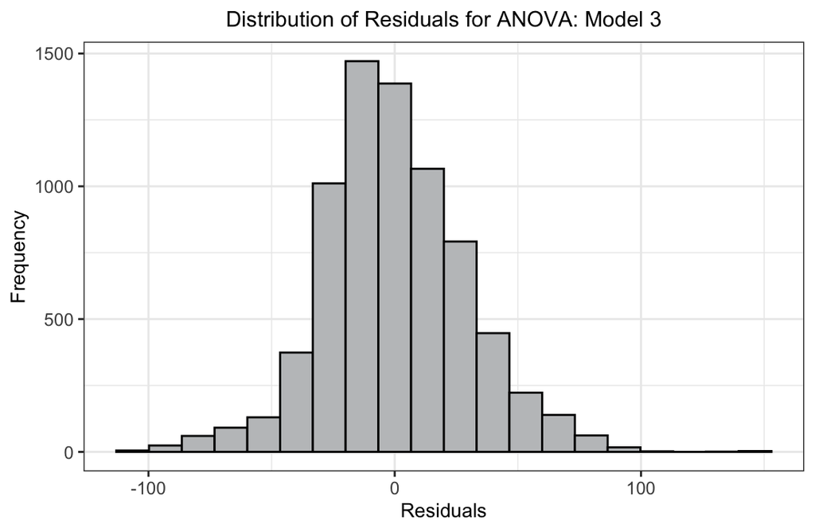

```r
ggplot(mapping = aes(x = residuals(twa3))) +
  geom_histogram(color = "black", fill = "#c0c2c4", bins = 20) +
  labs(title = "Distribution of Residuals for ANOVA: Model 3",
       x = "Residuals", y = "Frequency") +
  theme_bw() +
  theme(plot.title = element_text(hjust = 0.5, size = 11),
        axis.title = element_text(size = 10),
        axis.text.x = element_text(size = 9),
        axis.text.y = element_text(size = 9))
```

The ANOVA outputs for Model 3 are displayed below.

```r
anova_table <- data.frame(
  Variable = c("Number of Cylinders", "Fuel Type",
               "Number of Cylinders : Fuel Type", "Residuals"),
  Df = c("6", "4", "7", "7,287"),
  `Sum Sq` = c("15,746,174", "16,437", "356,508", "6,245,676"),
  `Mean Sq` = c("2,624,362", "4,109", "50,930", "857"),
  `F-Value` = c("3,061.92", "4.80", "59.42", "-"),
  `P-Value` = c("<0.001", "<0.001", "<0.001", "-"))

gt(anova_table) %>%
  cols_label(Variable = md("**Variable**"), Df = md("**Df**"), `Sum.Sq` = md("**Sum Sq**"),
             `Mean.Sq` = md("**Mean Sq**"), `F.Value` = md("**F Value**"),
             `P.Value` = md("**P Value**")) %>%
  cols_align("center")
```

| **Variable** | **Df** | **Sum Sq** | **Mean Sq** | **F Value** | **P Value** |
| --- | --- | --- | --- | --- | --- |
| Number of Cylinders | 6 | 15,746,174 | 2,624,362 | 3,061.92 | <0.001 |
| Fuel Type | 4 | 16,437 | 4,109 | 4.80 | <0.001 |
| Number of Cylinders : Fuel Type | 7 | 356,508 | 50,930 | 59.42 | <0.001 |
| Residuals | 7,287 | 6,245,676 | 857 | - | - |

### Linear Regression

Two linear regression models are built. Model 1, the first linear regression model, is a simple linear regression model with no control variables. The dependent variable in this model is CO2 Emissions, and the independent variable is Engine Size. One of the main assumptions of linear regression is that the model’s residuals are normally distributed. A residual versus fitted plot was generated from Model 1. A clear diminishing relationship is present in the plot, indicating that a polynomial transformation needs to be applied to Engine Size to fit the assumption of linear regression mentioned above. The residual vs. fitted plot is displayed below.

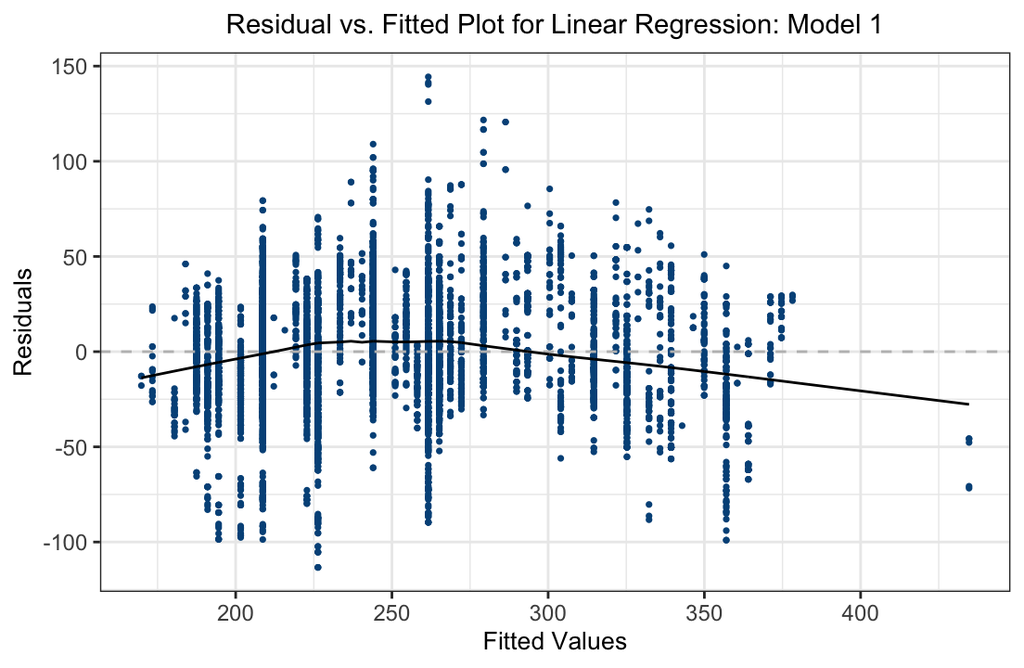

```r
lm1 <- lm(Emissions ~ Engine_Size, data = data)

model_frame3 <- fortify(lm1)

smoothed3 <- as.data.frame(with(model_frame3, lowess(x = .fitted, y = .resid)))

ggplot(data = lm1, aes(x = .fitted, y = .resid)) +
  geom_point(color = "#005288", size = 0.6) +
  geom_hline(yintercept = 0, color = "grey", linetype = "dashed") +
  geom_path(data = smoothed3, aes(x = x, y = y), col = "black") +
  labs(title = "Residual vs. Fitted Plot for Linear Regression: Model 1",
       x = "Fitted Values", y = "Residuals") +
  theme_bw() +
   theme(plot.title = element_text(hjust = 0.5, size = 11),
        axis.title = element_text(size = 10),
        axis.text.x = element_text(size = 9),
        axis.text.y = element_text(size = 9))
```

Prior to building Model 2, three new binary variables are created. The first new binary variable, Premium Gas, represents whether the vehicle uses premium gasoline. The point biserial correlation is generated between CO2 Emissions and Premium Gas, and the coefficient from the correlation test is 0.24. Because a point biserial correlation coefficient above 0.20 is deemed moderate, this result indicates a moderate positive correlation between the variables. Therefore, Premium Gas will be included as a control variable in Model 2. The second new binary variable, Four Cylinders, represents whether the vehicle has a four-cylinder engine. From initial research, the most common number of cylinders in a vehicle’s engine is four. Also, the research displayed that vehicles with four-cylinder engines are more fuel-efficient than vehicles with more than four cylinders. These are the main reasons engines with four cylinders will be controlled for. The point biserial correlation is generated between CO2 Emissions and Four Cylinders, and the coefficient from the correlation test is −0.70. This result indicates a strong negative correlation between the variables. This binary variable will also be included as a control variable in Model 2. The third new binary variable, SUV, represents whether the vehicle is an SUV. Research showed that SUVs emit higher CO2 Emissions than smaller passenger cars. The point biserial correlation is generated between CO2 Emissions and SUV, and the coefficient from the correlation test is 0.14. This result indicates a weak positive correlation between the variables. Even though a moderate correlation is not present, SUV will be included in Model 2 to see if it has a statistically significant relationship with the dependent variable.

Model 2, the second linear regression model, is a multivariate linear regression model. The dependent variable is CO2 emissions. Next, Engine Size is the independent variable of interest in the model. There are five control variables. All three of the newly generated binary variables that were mentioned above are control variables in this model. Last, two additional dummy variables are included as control variables from the variable Location Make, which represents the location the vehicle was manufactured in. The first dummy variable from Location Make is EUR, which represents whether the vehicle’s manufacturing location is in Europe. The second dummy variable from Location Make is USA, which represents whether the vehicle’s manufacturing location is in the United States. Because of the dummy variable trap, the third dummy variable, Asia, from Location Make is dropped.

Now it will be investigated whether Model 2 follows certain assumptions regarding linear regression. First, multicollinearity must not be present in the model. To see if multicollinearity is present, the variance inflation factor (VIF) of each variable in Model 2 is generated. The general rule of thumb is that if a variable has a VIF below 5, it is acceptable to include the model, and multicollinearity is likely avoided. All of the VIFs from variables in the model fit this criterion, indicating this assumption of linear regression is met. Second, the residuals versus fitted plot is examined to see whether the variance is constant in the residuals. The variance is constant, meaning the residuals are homoscedastic, and this assumption of linear regression is met. The residual vs. fitted plot is displayed below.

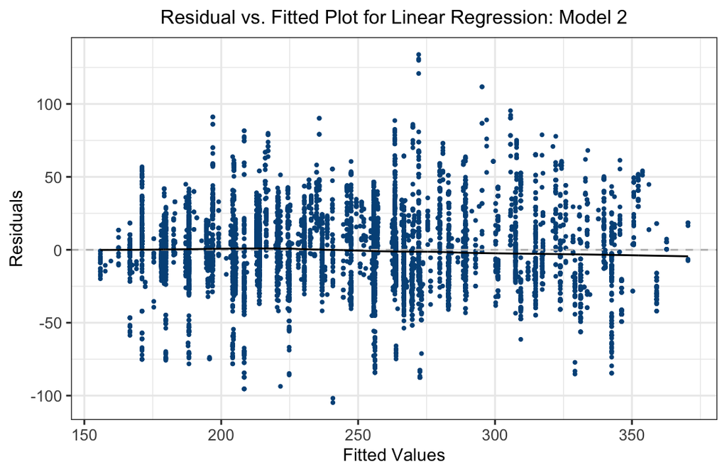

```r
data <- data %>%
  mutate(Prem_Gas = if_else(Fuel_Type == "Z", 1, 0),
         Four_Cyl = if_else(Cylinders == "4", 1, 0),
         SUV = if_else(Class %in% c("Small SUV", "Standard SUV"), 1, 0),
         Squared_Engine_Size = Engine_Size^2)

pbc1 <- cor.test(data$Prem_Gas, data$Emissions)

print(pbc1)

pbc2 <- cor.test(data$Four_Cyl, data$Emissions)

print(pbc2)

pbc3 <- cor.test(data$SUV, data$Emissions)

print(pbc3)

lm2 <- lm(Emissions ~ Engine_Size + Squared_Engine_Size + Four_Cyl + Prem_Gas +
                      Location_Make + SUV, data = data)

summary(lm2)

vif(lm2)

model_frame4 <- fortify(lm2)

smoothed4 <- as.data.frame(with(model_frame4, lowess(x = .fitted, y = .resid)))

ggplot(data = lm2, aes(x = .fitted, y = .resid)) +
  geom_point(color = "#005288", size = 0.6) +
  geom_hline(yintercept = 0, color = "grey", linetype = "dashed") +
  geom_path(data = smoothed4, aes(x = x, y = y), col = "black") +
  labs(title = "Residual vs. Fitted Plot for Linear Regression: Model 2",
       x = "Fitted Values", y = "Residuals") +
  theme_bw() +
   theme(plot.title = element_text(hjust = 0.5, size = 11),
        axis.title = element_text(size = 10),
        axis.text.x = element_text(size = 9),
        axis.text.y = element_text(size = 9))
```

Finally, the residuals from the model must be normally distributed. A histogram is produced below from the residuals of Model 2, and they are normally distributed. Overall, Model 2 fits all three assumptions mentioned regarding linear regression.

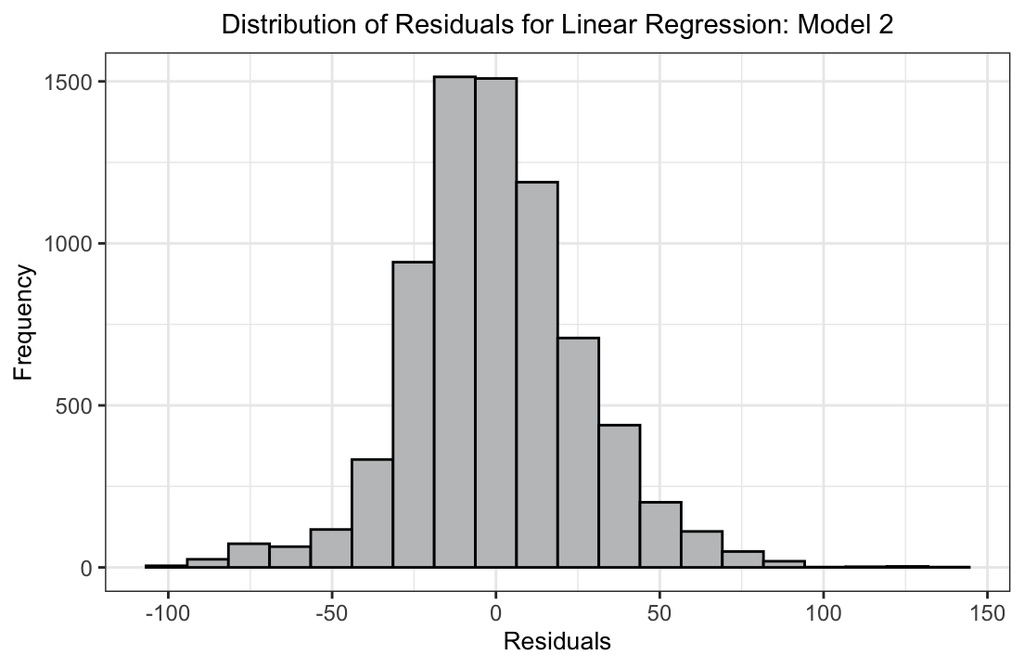

```r
ggplot(mapping = aes(x = residuals(lm2))) +
  geom_histogram(color = "black", fill = "#c0c2c4", bins = 20) +
  labs(title = "Distribution of Residuals for Linear Regression: Model 2",
       x = "Residuals", y = "Frequency") +
  theme_bw() +
  theme(plot.title = element_text(hjust = 0.5, size = 11),
        axis.title = element_text(size = 10),
        axis.text.x = element_text(size = 9),
        axis.text.y = element_text(size = 9))
```

Because the assumptions of linear regression are met, the statistically significant coefficients from Model 2 will be interpreted. In Model 2, the independent variable of interest, the quadratic of Engine Size, is statistically significant at the 1% significance level. Because Engine Size is a quadratic term, it requires the use of an initial value to interpret the coefficients. Thus, the change in CO2 emission per liter change in engine size is 52.6959 + (-2.7414 * Engine Size), and the initial value of Engine Size is 1. After performing the necessary calculations with the initial value of 1, the marginal effect is 49.95. Model 2 displays that as a vehicle’s engine size increases, the marginal effect becomes less. For example, given the initial value of 5, the marginal effect is 38.98.

Now both the r-squared value and adjusted r-squared values for Model 2 are observed. The r-squared value in this model displays the portion of the variation in CO2 Emissions explained by the independent variables. In Model 2, the r-squared value is 0.7704, indicating that 77.04% of the variation in CO2 Emissions is explained by the independent variables in the model. An r-squared value above 70% indicates a strong effect size in the mode. Clearly, the independent variables in Model 2 have strong explanatory power. Because six independent variables are included in Model 2, the adjusted r-squared value is also looked at. The adjusted r-squared displays the same measurement as the r-squared value, except the adjusted r-squared value accounts for a penalty for each additional independent variable added after the initial one. The adjusted r-squared value for Model 2 is 0.7702, which is almost the same as the model’s r-squared value. Overall, this finding shows that the high r-squared value generated from Model 2 is not misleading because the also high adjusted r-squared value confirms that the model is not overfitting the data.

The regression outputs for Model 2 are displayed below.

```r
tbl_regression(lm2) %>%
  modify_header(update = list(label = "**Variable**",
                              estimate = "**Coefficient**")) %>%
  add_glance_table(include = c(nobs, r.squared)) %>%
  modify_footnote(everything() ~ NA, abbreviation = TRUE)
```

| **Variable** | **Coefficient** | **95% CI** | **p-value** |
| --- | --- | --- | --- |
| Engine_Size | 53 | 49, 56 | <0.001 |
| Squared_Engine_Size | -2.7 | -3.1, -2.4 | <0.001 |
| Four_Cyl | -2.8 | -5.1, -0.46 | 0.019 |
| Prem_Gas | 8.7 | 7.0, 10 | <0.001 |
| Location_Make |  |  |  |
| Asia | — | — |  |
| EUR | 17 | 15, 19 | <0.001 |
| USA | 16 | 14, 18 | <0.001 |
| SUV | 16 | 15, 18 | <0.001 |
| No. Obs. | 7,305 |  |  |
| R² | 0.770 |  |  |

### Logistic Regression

The median of CO2 emissions for vehicles in the data set is 245 g/km. A logistic regression model is built to answer the following question: What vehicle features are associated with CO2 emissions greater than 245 g/km? A binary variable named Bin_Em is created to indicate whether a vehicle’s CO2 emissions are above 245 g/km. Bin_Em is the dependent variable in Model 1, which is the first logistic regression model. In logistic regression, the dependent variable must be binary, and this condition is satisfied. In this model, the independent variable of interest is engine size. The relationship between the two variables will be displayed in a scatter plot. This graph will allow for the relationship of the variables to be understood before Model 1 is built.

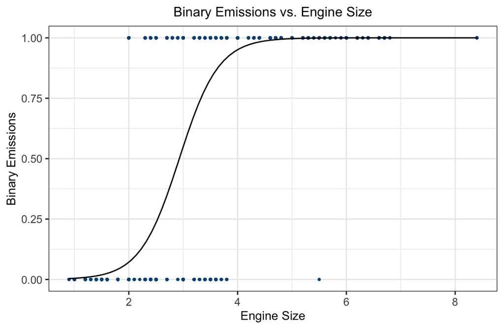

```r
median(data$Emissions)

data <- data %>%
  mutate(Bin_Em = if_else(Emissions > median(Emissions), 1, 0),
         USA = if_else(Location_Make == "USA", 1, 0))

ggplot(data = data, mapping = aes(x = Engine_Size, y = Bin_Em)) +
  geom_point(color = "#005288", size = 0.6) +
  geom_smooth(method = glm, se = FALSE, col = "black", size = 0.5,
              method.args = list(family=binomial)) +
  labs(title = "Binary Emissions vs. Engine Size",
       x = "Engine Size", y = "Binary Emissions") +
  theme_bw() +
  theme(plot.title = element_text(hjust = 0.5, size = 11),
        axis.title = element_text(size = 10),
        axis.text.x = element_text(size = 9),
        axis.text.y = element_text(size = 9))
```

Model 1 is now built with the variables specified earlier. Other than engine size, no independent variables are included in this model. This approach will ensure a better understanding of how the effect has changed once the control variables are added.

```r
glm1 <- glm(Bin_Em ~ Engine_Size, family = binomial(link = logit), data = data)

summary(glm1)

tbl_regression(glm1, exp = TRUE) %>%
  modify_header(update = list(label = "**Variable**")) %>%
  add_glance_table(include = (nobs)) %>%
  modify_footnote(everything() ~ NA, abbreviation = TRUE)
```

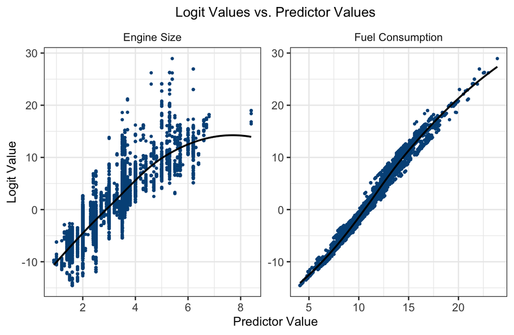

```r
glm2 <- glm(Bin_Em ~ Engine_Size + Fuel_Consumption + Prem_Gas + USA + SUV,
            family = binomial(link = logit), data = data)

summary(glm2)

vif(glm2)

df_model <- data %>%
  select(Engine_Size, Fuel_Consumption) %>%
  rename(`Engine Size` = Engine_Size, `Fuel Consumption` = Fuel_Consumption)

predictors <- colnames(df_model)

df_model$probabilities <- glm2$fitted.values

df_model <- df_model %>%
  mutate(logit = log(probabilities/(1 - probabilities))) %>%
  select(-probabilities) %>%
  gather(key = "predictors", value = "predictor.value", -logit)

ggplot(data = df_model, mapping = aes(x = predictor.value, y = logit)) +
  geom_point(color = "#005288", size = 0.6) +
  geom_smooth(method = loess, se = FALSE, col = "black", size = 0.7) +
  facet_wrap(~predictors, scales = "free") +
  labs(title = "Logit Values vs. Predictor Values",
       x = "Predictor Value", y = "Logit Value") +
  theme_bw() +
  theme(plot.title = element_text(hjust = 0.5, size = 11),
        axis.title = element_text(size = 10),
        axis.text.x = element_text(size = 9),
        axis.text.y = element_text(size = 9),
        strip.background = element_blank())
```

Interpreting marginal effects is another method to analyze results from logistic regression models. Thus, the marginal effects for the variables that are statistically significant in Model 2 will be interpreted. Holding all other variables at their observed values, on average, a one-liter increase in the engine size is associated with a 7% increase in the probability of a vehicle’s CO2 emissions being above the median value of 245 g/km. Holding all other variables at their observed values, on average a one liter per 100 km increase in fuel consumption is associated with an 11% increase in the probability of a vehicle’s CO2 emissions being above the median value of 245. Last, holding all other variables at their observed values, SUVs are associated with a 3% increase in their probability of being above the median value of 245 g/km than non-SUVs on average.

There is no r-squared for logistic regression. Instead, a metric called McFadden’s r-squared can be used to evaluate the explanatory power of the model. For McFadden’s r-squared, a value close to 0 has little predictive power, whereas a value greater than 0.40 indicates that the model fits the data extremely well. In model 2, the value is 0.73, which indicates that the model performs extremely well with the data.

```r
margins(glm2, variables = c("Engine_Size", "Fuel_Consumption", "SUV"))

pR2(glm2)["McFadden"]
```

The regression outputs for Model 2 are displayed below.

```r
tbl_regression(glm2, exp = TRUE) %>%
  modify_header(update = list(label = "**Variable**")) %>%
  add_glance_table(include = (nobs)) %>%
  modify_footnote(everything() ~ NA, abbreviation = TRUE)
```

| **Variable** | **OR** | **95% CI** | **p-value** |
| --- | --- | --- | --- |
| Engine_Size | 3.33 | 2.77, 4.01 | <0.001 |
| Fuel_Consumption | 7.13 | 6.21, 8.24 | <0.001 |
| Prem_Gas | 1.20 | 0.93, 1.55 | 0.2 |
| USA | 1.03 | 0.79, 1.34 | 0.8 |
| SUV | 1.78 | 1.40, 2.25 | <0.001 |
| No. Obs. | 7,305 |  |  |

### K-Nearest Neighbors

A random seed is set to make the process of reordering rows based on their indices reproducible in the future. Then, the rows in the data are reordered. The data are split into a training set and a test set. The training data consist of 70% of the original data, and the test data consist of the other 30%. CO2 Emissions will be the variable that Model 1, the first k-nearest neighbors model, is trying to predict. Model 1 will not use any special resampling or multiple-fold validation. The training data are used to train the k-nearest neighbors algorithm to predict the CO2 Emissions of vehicles. Engine size and fuel consumption will be the two predictors for Model 1. The rows for each vehicle in the training data will be used as the “neighbors” for predicting the prices of vehicles in the test data. For each vehicle in the test data, the average CO2 emissions of its neighbors is calculated. Because there are predicted values for the CO2 Emissions of vehicles in the test data, it is possible to find how well Model 1 predicts the CO2 Emissions of vehicles by comparing the actual values of CO2 emissions for the vehicles to the predicted ones. An error metric is generated, which is the root mean square error, (RMSE) to judge how well Model 1 performs at predicting a vehicle’s level of CO2 emissions. The root mean square error of this model is 9.95.

```r
ml_data <- data

set.seed(1)

rows <- sample(nrow(ml_data))

ml_data <- ml_data[rows, ]

train_indices <- createDataPartition(y = ml_data$Emissions,
                                     p = 0.7,
                                     list = FALSE)

train <- ml_data[train_indices, ]

test <- ml_data[-train_indices, ]

train_control1 <- trainControl(method = "none")

knn1 <- train(Emissions ~ Engine_Size + Fuel_Consumption,
              data = train,
              method = "knn",
              trControl = train_control1)

test_predictions1 <- predict(knn1, newdata = test)

test <- cbind(test, test_predictions1)

test <- test %>%
  rename(Emissions_Predictions1 = test_predictions1) %>%
  relocate(Emissions_Predictions1, .after = Emissions)

rmse1 <- test %>%
  mutate(squared_error = (Emissions - Emissions_Predictions1)^2) %>%
  select(squared_error) %>%
  summarize(rmse = sqrt(mean(squared_error)))
```

Model 2, the second k-nearest neighbors model in this analysis includes three predictors for CO2 Emissions rather than just two, like the previous model. The same two predictors in the previous model are included in this one. Engine Cylinders is included in Model 2. The goal of adding this third predictor is to lower the RMSE value, thus getting more accurate predictions for CO2 Emissions in the test data. Hyper parameter optimization is implemented in this model to see what number of neighbors produces the lowest RMSE. This method was used by grid searching along a domain of 1 to 20 for the optimal number of neighbors. This number ends up being 1. Also, cross-validation is used in this model. Below is a plot that displays the cross validated search grid results.

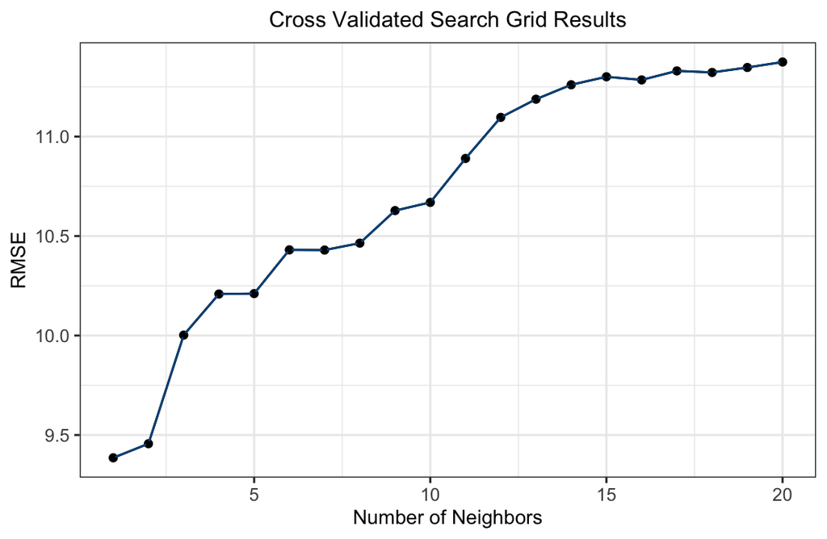

```r
knn_grid2 <- expand.grid(k = 1:20)

train_control2 <- trainControl(method = "cv", number = 5)

knn2 <- train(Emissions ~ Engine_Size + Fuel_Consumption + Cylinders,
              data = train,
              method = "knn",
              trControl = train_control2,
              tuneGrid = knn_grid2)

ggplot(data = knn2) +
  geom_line(color = "#005288") +
  geom_point(color = "black", size = 0.5) +
  labs(title = "Cross Validated Search Grid Results",
       x = "Number of Neighbors", y = "RMSE") +
  theme_bw() +
  theme(plot.title = element_text(hjust = 0.5, size = 11),
        axis.title = element_text(size = 10),
        axis.text.x = element_text(size = 9),
        axis.text.y = element_text(size = 9),
        strip.background = element_blank())
```

The RMSE for Model 2 is 9.26, which is lower than the RMSE of the model above. Overall, Model 2 is better at predicting the CO2 Emissions of a vehicle than the initial k-nearest neighbors model.

```r
test_predictions2 <- predict(knn2, newdata = test)

test <- cbind(test, test_predictions2)

test <- test %>%
  rename(Emissions_Predictions2 = test_predictions2) %>%
  relocate(Emissions_Predictions2, .after = Emissions_Predictions1)

rmse2 <- test %>%
  mutate(squared_error = (Emissions - Emissions_Predictions2)^2) %>%
  select(squared_error) %>%
  summarize(rmse = sqrt(mean(squared_error)))
```

## V. Conclusion

Many noteworthy findings emerged from this statistical analysis of the relationship between vehicles’ CO2 emission and their characteristics. The exploratory data analysis employed descriptive statistics, visualization, and correlation tests. A significant finding was the strong linear relationship between vehicles’ CO2 emissions and engine size. This was shown through a high Pearson correlation coefficient of 0.85. Another insightful finding was a similarly strong correlation between CO2 emissions and engine cylinders. Because cylinders were an ordinal variable, the Spearman correlation coefficient between cylinders and CO2 emissions was generated, which was 0.85. This relationship is nonlinear, unlike that of CO2 emissions and engine size.

The statistical modeling in this analysis provided many noteworthy new insights. The ANOVA, linear regression, and logistic regression models all highlighted key relationships between CO2 emissions and the various explanatory variables. A key finding was the statistically significant relationship between CO2 emissions and the quadratic term of engine size for vehicles. Interpreting this term provided further insight into the relationship of the variables—the marginal effect decreases as a vehicle’s engine size increases. The machine learning models using k-nearest neighbors indicated the variables that are strong predictors for a vehicle’s level of CO2 emissions. The machine learning model with the lowest RMSE included the predictor’s engine size, fuel consumption, and cylinders. Overall, the results validate the majority of the initial research findings, and individuals can better understand what characteristics of vehicles contribute to the release of excessive CO2 emissions into the Earth’s atmosphere.